# OA stratification

Stratification of OA PLC patients RNA-seq data quantified with kallisto and the output sumarised to a counts matrix using txi-import

Set up the code and load the libraries

In total 10 nonOA and 60 OA PLC samples. Patient details gives mankin grade, bmi, age, sex, date of sequencing, and pain scores.

Set up the data

```r
#load counts matrix from txi-import using kallisto abundance matrices
load("data/txi.RData")
#load patient details
patientDetails<-read.csv("data/patientDetails_all_withMed.csv",stringsAsFactors = F)
#load the human protein interaction network
humanNetwork<-read.delim("data/HumanNetwork.txt",header = F)
humanNetwork<-graph.data.frame(humanNetwork,directed = F)
#match up the order of the patient details and the expression data
txi$counts <- txi$counts[ ,match(unique(as.character(patientDetails$name)),colnames(txi$counts))]
txi$abundance <- txi$abundance[ ,match(unique(as.character(patientDetails$name)),colnames(txi$abundance))]
txi$length <- txi$length[ ,match(unique(as.character(patientDetails$name)),colnames(txi$length))]
```

Comparison of the OA and nonOA GAG and DNA

```r
#Load the stats
GAG<-read.csv("data/GAG.csv")
DNA<-read.csv("data/DNA.csv")
patientDetails$OA<-ifelse(grepl("SH0", patientDetails$name),"OA","NonOA")
patientDetails<-patientDetails[!duplicated(patientDetails$name),]

#make plot for GAG
patientGAG<- ggplot(GAG, aes ( x= Group, y= Average,fill=Group))+ geom_boxplot()+scale_fill_manual(values = c("lightgrey", "white")                                       )+ylab(expression(paste(GAG*' '*mu*'g/'*mg)))+xlab(label="Disease") +  theme_classic(base_size = 24) +theme(axis.title.x = element_blank()) +  guides(fill=FALSE)

#make plot for DNA
patientDNA<- ggplot(DNA, aes ( x= Group, y= Average,fill=Group))+ geom_boxplot()+scale_fill_manual(values = c("lightgrey", "white")                                                                            )+ylab(expression(paste(DNA*' '*mu*'g/'*mg)))+xlab(label="Disease") +  theme_classic(base_size = 24) +theme(axis.title.x = element_blank()) +  guides(fill=FALSE)

#make plot for Modified Mankin Score
patientScore<- ggplot(patientDetails, aes ( x= OA, y= Modified.Mankin.Score,fill=OA))+ geom_boxplot()+scale_fill_manual(values = c("lightgrey", "white")                                                                            )+ylab(label="Mankin Score")+xlab(label="Disease") +  theme_classic(base_size = 24) +theme(axis.title.x = element_blank()) +  guides(fill=FALSE)

#Make composite fig
SupplFig1<-ggdraw()+
    draw_plot(patientGAG, x=0, y=.5, width=0.5, height=.5,scale=0.9)+
    draw_plot(patientDNA, x=.5, y=.5, width=0.5, height=.5,scale=0.9) +
  draw_plot(patientScore, x=.33, y=0, width=0.5, height=0.5,scale=0.9) +
  draw_plot_label(label=LETTERS[1:3],x=c(0,0.5,0.33), y=c(1,1,0.5), fontface='bold',size = 25)




save_plot("results/SupplFig1.png",SupplFig1,base_height = 8,base_width = 12,dpi=600)
```

PCA analysis of the entire expression dataset

```r
#load patient details
patientDetails<-read.csv("data/patientDetails_all_withMed.csv",stringsAsFactors = F)
#Get the batches and variance stabilise the data
batches<-patientDetails[!duplicated(patientDetails$name),"batch"]
colData<-data.frame(batches)
getPalette = colorRampPalette(brewer.pal(8, "Set1"))
dds<-DESeqDataSetFromTximport(txi,colData,~1)
```

```
using just counts from tximport
```

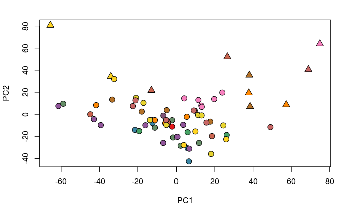

```r
dds<-varianceStabilizingTransformation(assay(dds))
#keep protein coding only to reduce complexity of clustering
endf <- GenomicFeatures::genes(EnsDb.Hsapiens.v79, return.type="DataFrame")
use<-rownames(dds) %in% endf[ endf$gene_biotype=="protein_coding","gene_id"]
dds<-dds[use,]
#soft filtering for expression
use <- apply(dds, 1, function(k) mean(k > 5)) > 0.5
dds<-dds[use,]
#PCA
pca<-prcomp(t(as.matrix(dds)))
comp <- data.frame(pca$x[,1:2])
Disease<-rep(1,70)
Disease[grep("MRI",colnames(txi$counts))]<-2
Disease[grep("RJ",colnames(txi$counts))]<-2
plot(comp[,1:2], col="black",bg=getPalette(13)[as.numeric(batches)],pch=c(21,24)[as.numeric(Disease)],cex=1.5)
```

Batch effect correction with pSVA for the unsupervised clustering

```r
#correct counts matrix with pSVA
correctedMatrix.complete<-pSVA(as.matrix(dds),batches,NULL)
```

```
Number of significant surrogate variables is:  11
Iteration (out of 5 ):1  2  3  4  5
```

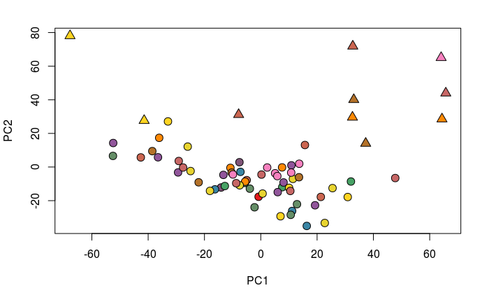

```r
#PCA and plot
pca<-prcomp(t(as.matrix(correctedMatrix.complete)))
comp <- data.frame(pca$x[,1:2])
Disease<-rep(1,70)
Disease[grep("MRI",colnames(correctedMatrix.complete))]<-2
Disease[grep("RJ",colnames(correctedMatrix.complete))]<-2
plot(comp[,1:2], col="black",bg=getPalette(13)[as.numeric(batches)],pch=c(21,24)[as.numeric(Disease)],cex=1.5)
```

PCA of the discovery cohort - first 54 columns

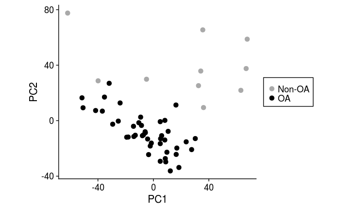

```r
#PCA and plot
pca<-prcomp(t(as.matrix(correctedMatrix.complete[,1:54])))
comp <- data.frame(pca$x[,1:2])
#show OA vs nonOA in the discovery cohort
Disease<-rep("OA",54)
Disease[grep("MRI",colnames(correctedMatrix.complete))]<-"Non-OA"
Disease[grep("RJ",colnames(correctedMatrix.complete))]<-"Non-OA"
pca.discovery.plot<-ggplot(data=comp, aes(x=PC1, y=PC2, color= Disease)) + geom_point(size=3) + xlab("PC1") + ylab("PC2") +  coord_fixed() + scale_colour_manual(name=Disease,values = c("darkgrey","black"))+cowplot::theme_cowplot(font_size = 16) + theme(legend.title=element_blank(),legend.background =element_rect(fill="white",size=0.5, linetype="solid",colour ="black"))
pca.discovery.plot
```

```r
NA
```

Match the expression data to the PPI for network contrained clustering - create seperate matrices for the discovery and validation cohort.

```r
#convert ensembl ID to gene symbol
endf <- GenomicFeatures::genes(EnsDb.Hsapiens.v79, return.type="DataFrame")
ens2gene <- as.data.frame(endf[,c("gene_id","gene_name")])
correctedMatrix.complete<-as.data.frame(correctedMatrix.complete)
correctedMatrix.complete$mean<-rowMeans(correctedMatrix.complete)
correctedMatrix.complete<-merge(correctedMatrix.complete,ens2gene,by.x="row.names",by.y="gene_id")
correctedMatrix.complete <- correctedMatrix.complete %>% group_by(gene_name) %>%  slice(which.max(mean)) %>% as.data.frame
#filter the network based on expressed genes
use<-na.omit(match(correctedMatrix.complete$gene_name,V(humanNetwork)$name))
OA.network<-induced.subgraph(humanNetwork,use)
OA.network<-decompose.graph(OA.network)[[1]]
#make the 44 patient discovery matrix
use<-na.omit(match(V(OA.network)$name,correctedMatrix.complete$gene_name))
discoveryMatrix<-correctedMatrix.complete[use,]
rownames(discoveryMatrix)<-discoveryMatrix$gene_name
discoveryMatrix<-discoveryMatrix[,c(-1,-72,-73)]
controls<-c(grep("MRI",colnames(discoveryMatrix)),grep("RJ",colnames(discoveryMatrix)))
discoveryMatrix<-discoveryMatrix[,-controls]
discoveryMatrix<-discoveryMatrix[,1:44]
#make the 16 patient validation matrix
validationMatrix<-correctedMatrix.complete[use,]
rownames(validationMatrix)<-validationMatrix$gene_name
validationMatrix<-validationMatrix[,c(-1,-72,-73)]
controls<-c(grep("MRI",colnames(validationMatrix)),grep("RJ",colnames(validationMatrix)))
validationMatrix<-validationMatrix[,-controls]
validationMatrix<-validationMatrix[,45:60]
```

Calculate the influence network from the PPI network - takes a fair while to run

networkNMF example - ran 500 times on multi node cluster - very time consuming

Use inline C code to define the NMF model.

Standard NMF for comparison - much faster

Make consensus matrices for the standard NMF

```r
#load all the runs from NMF.
loadNMFRuns<-function(pred,k) {

  pred[,1]<-paste(pred[,1],rep(1:(dim(pred)[1]/39),each=39),sep="_")
  C<- table(pred[,2])
  V <- crossprod(table(pred[1:2]))
  V <-sweep(V,MARGIN=2,C,`/`)
  distMat<-as.dist(1-V)
  clust<-hclust(distMat,"ave")
  coph<-cophenetic(clust)
  cophenetic<-round(cor(distMat,coph),3)
  coph<-paste("coph=",round(cor(distMat,coph),3),sep="")
  sil<-round(mean(silhouette(as.numeric(cutree(clust,k)),distMat)[,3]),3)


  return(list(consensus=V,distance=distMat,dendro=cophenetic,coph=coph,clust=clust,sil=sil))

}
load("data/Lee_rank2_200317.RData")
load("data/Lee_rank3_200317.RData")
load("data/Lee_rank4_200317.RData")
NMF2.Lee<-loadNMFRuns(groups_2,2)
NMF3.Lee<-loadNMFRuns(groups_3,3)
NMF4.Lee<-loadNMFRuns(groups_4,4)
sil.Lee<-c(NMF2.Lee$sil,NMF3.Lee$sil,NMF4.Lee$sil)
load("data/NetNMF_R2_L25.RData")
load("data/NetNMF_R3_L25.RData")
load("data/NetNMF_R4_L25.RData")
NMF2.Net<-loadNMFRuns(netNMF.2,2)
NMF3.Net<-loadNMFRuns(netNMF.3,3)
NMF4.Net<-loadNMFRuns(netNMF.4,4)
#Make the mean siloutette plot
sil.Net<-c(NMF2.Net$sil,NMF3.Net$sil,NMF4.Net$sil)
sil<-data.frame(Method=c(rep("NetNMF",3),rep("NMF",3)),Rank=c(2:4,2:4),Silhouette=c(sil.Net,sil.Lee))
meanSilPlot<-ggplot(sil,aes(x=Rank,y=Silhouette,group=Method))+geom_bar(aes(fill=Method),position = "dodge", stat="identity")+ ylab("Mean Silhouette Width")+  scale_fill_manual(values = c("black", "lightgrey"))+cowplot::theme_cowplot(font_size = 20)
#individual silhouette scores
siloutetteScores<-as.data.frame(silhouette(as.numeric(cutree(NMF2.Net$clust,2)),NMF2.Net$distance)[,c(1,3)])
siloutetteScores<-siloutetteScores[ order(siloutetteScores$cluster,-siloutetteScores$sil_width),]
siloutetteScores$cluster<-ifelse(siloutetteScores$cluster=="1","GroupA","GroupB")
silPlot<-ggplot(siloutetteScores,aes(x=1:44,y=sil_width,group=as.factor(cluster)))+geom_bar(aes(fill=as.factor(cluster)),position = "dodge", stat="identity") + ylab("Silhouette Width") + scale_fill_manual(values = c("black","darkgrey")) +  cowplot::theme_cowplot(font_size = 20) + theme(axis.line.x=element_blank(),axis.title.x=element_blank(),axis.text.x=element_blank(),axis.ticks.x=element_blank(),legend.title=element_blank())
#make the consensus maps for all the netNMF and standard NMF runs
NMF2.Net.map<-grid::grid.grabExpr(consensusmap(NMF2.Net$consensus,main="",labRow=NA,labCol=NA,col="royalblue4",treeheight = 0,fontsize = 10,legend=F),wrap=T)
NMF3.Net.map<-grid::grid.grabExpr(consensusmap(NMF3.Net$consensus,main="",labRow=NA,labCol=NA,col="royalblue4",treeheight = 0,fontsize = 10,legend=F),wrap=T)
NMF4.Net.map<-grid::grid.grabExpr(consensusmap(NMF4.Net$consensus,main="",labRow=NA,labCol=NA,col="royalblue4",treeheight = 0,fontsize = 10,legend=F),wrap=T)
NMF2.Lee.map<-grid::grid.grabExpr(consensusmap(NMF2.Lee$consensus,main="k=2",labRow=NA,labCol=NA,col="royalblue4",treeheight = 0,fontsize = 10,legend=F),wrap=T)
NMF3.Lee.map<-grid::grid.grabExpr(consensusmap(NMF3.Lee$consensus,main="k=3",labRow=NA,labCol=NA,col="royalblue4",treeheight = 0,fontsize = 10,legend=F),wrap=T)
NMF4.Lee.map<-grid::grid.grabExpr(consensusmap(NMF4.Lee$consensus,main="k=4",labRow=NA,labCol=NA,col="royalblue4",treeheight = 0,fontsize = 10,legend=F),wrap=T)
consensusMap<-gridExtra::arrangeGrob(NMF2.Net.map,NMF3.Net.map,NMF4.Net.map,NMF2.Lee.map,NMF3.Lee.map,NMF4.Lee.map,nrow=2,left="NetNMF                                    NMF")

silPlots<-plot_grid(silPlot,meanSilPlot)
Figure1<-ggdraw()+
    draw_plot(pca.discovery.plot, x=0, y=.5, width=0.5, height=.5)+
    draw_plot(consensusMap, x=.5, y=.5, width=0.4, height=.5) +
  draw_plot(silPlot, x=0, y=0, width=0.5, height=0.5,scale=0.9) +
  draw_plot(meanSilPlot, x=0.5, y=0, width=0.5, height=0.5,scale=0.9) +
  draw_plot_label(label=LETTERS[1:4],x=c(0,0.5,0,0.5), y=c(1,1,0.5,0.5), fontface='bold',size = 25)
save_plot("results/Figure1.png",Figure1,base_height = 8,base_width = 12,dpi=600)
```

Extract the subgroup predictions

```r
#remove the poorly clustered samples
remove<-which(silhouette(as.numeric(cutree(NMF2.Net$clust,2)),NMF2.Net$distance)[,3]<0)
#define the subgroups
groups<-stack(cutree(NMF2.Net$clust,2)[-remove])
groups<-groups[ order(groups$ind),]
removeSampleNames<-stack(cutree(NMF2.Net$clust,2)[remove])$ind
remove<-which(colnames(txi$abundance) %in% removeSampleNames)
# make the subgroup vector
subgroups<-rep("validation",70)
controls<-c(grep("MRI",colnames(txi$counts)),grep("RJ",colnames(txi$counts)))
subgroups[controls]<-"nonOA"
subgroups[which(colnames(txi$counts) %in% groups[groups$values==1,2] )] <-"GroupA"
subgroups[which(colnames(txi$counts) %in% groups[groups$values==2,2] )] <-"GroupB"
```

Subgroup patient stats

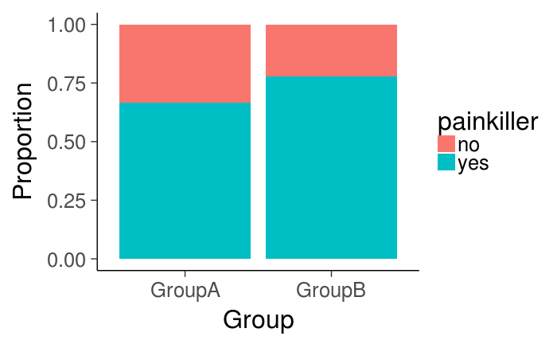

```r
#Statistics of the subgroups
patientDetails<-read.csv("data/patientDetails_all_withMed.csv",stringsAsFactors = F)
patientDetails<-patientDetails[ !duplicated(patientDetails$name),]
patientDetails$Group<-subgroups
patientDetails<-patientDetails[ !patientDetails$Group %in% c("validation","nonOA"),]
#make the drug columns
patientDetails$painkiller<-ifelse(grepl(paste(c("aspirin","paracetamol","COCODAMOL","TRAMADOL"),collapse="|"),patientDetails$ANALGESICS.PREOP, ignore.case = T),"yes","no")
patientDetails$nsaid<-ifelse(grepl(paste(c("IBUPROFEN","NAPROXEN"),collapse="|"),patientDetails$ANALGESICS.PREOP, ignore.case = T),"yes","no")
patientDetails$statin<-ifelse(grepl(paste(c("statin"),collapse="|"),patientDetails$OTHER.MEDICATIONS, ignore.case = T),"yes","no")
patientSex<-ggplot(patientDetails, aes ( x= Group, fill= Sex))+ geom_bar(position="fill")+scale_fill_manual(values = c("lightgrey", "darkgrey"))+ylab(label="Proportion")+xlab(label="Group") + theme_classic(base_size = 24) + scale_color_manual(values = "black") + theme(axis.title.x = element_blank())
ggplot(patientDetails, aes ( x= Group, fill= painkiller))+ geom_bar(position="fill")+ylab(label="Proportion")+xlab(label="Group")  + theme_classic(base_size = 24)
```

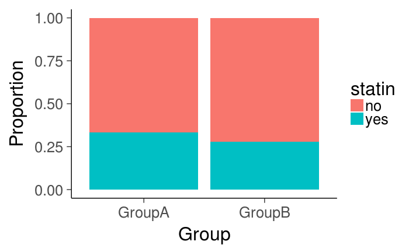

```r
ggplot(patientDetails, aes ( x= Group, fill=statin))+ geom_bar(position="fill")+ylab(label="Proportion")+xlab(label="Group")+  theme_classic(base_size = 24)
```

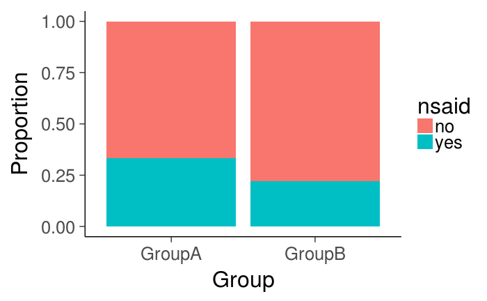

```r
ggplot(patientDetails, aes ( x= Group, fill= nsaid))+ geom_bar(position="fill")+ylab(label="Proportion")+xlab(label="Group") + theme_classic(base_size = 24)
```

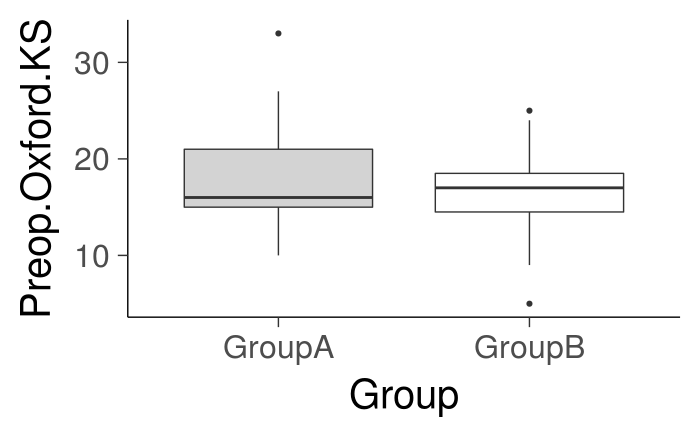

```r
patientAge<-ggplot(patientDetails, aes ( x= Group, y= Age,fill=Group))+ geom_boxplot()+scale_fill_manual(values = c("lightgrey", "white")                                                                        )+ylab(label="Age")+xlab(label="Group") +  theme_classic(base_size = 24) + guides(fill=FALSE) +theme(axis.title.x = element_blank())
patientBMI<- ggplot(patientDetails, aes ( x= Group, y= BMI,fill=Group))+ geom_boxplot()+scale_fill_manual(values = c("lightgrey", "white")                                                                            )+ylab(label="BMI")+xlab(label="Group") +  theme_classic(base_size = 24) +theme(axis.title.x = element_blank()) +  guides(fill=FALSE)
ggplot(patientDetails, aes ( x= Group, y= Preop.Oxford.KS..0.48.,fill=Group))+ geom_boxplot()+scale_fill_manual(values = c("lightgrey", "white")                                                                            )+ylab(label="Preop.Oxford.KS")+theme(axis.title.x = element_blank()) + theme_classic(base_size=30) + guides(fill=FALSE)
```

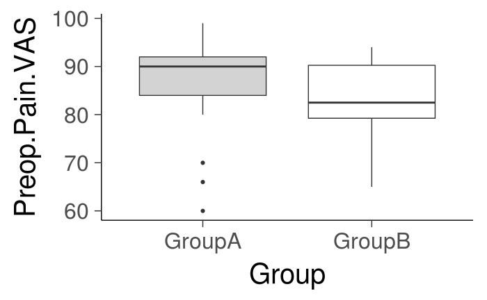

```r
ggplot(patientDetails, aes ( x= Group, y= Preop.Pain.VAS..0.100.,fill=Group))+ geom_boxplot()+scale_fill_manual(values = c("lightgrey", "white")                                                                            )+ylab(label="Preop.Pain.VAS")+xlab(label="Group") + theme_classic(base_size=30) + guides(fill=FALSE)
```

```r
ggplot(patientDetails, aes ( x= Group, y= KOOS.Pain..0.100.,fill=Group))+ geom_boxplot()+scale_fill_manual(values = c("lightgrey", "white")                                                                            )+ylab(label="KOOS.Pain")+xlab(label="Group") + theme_classic(base_size=30) + guides(fill=FALSE)
PatientMankin<-ggplot(patientDetails, aes ( x= Group, y= Modified.Mankin.Score ,fill=Group)) + geom_boxplot()+scale_fill_manual(values = c("lightgrey", "white"))+ylab(label="Mankin Score")+xlab(label="Group") + theme_classic(base_size=24) + theme(axis.title.y = element_text(size = rel(1))) + guides(fill=FALSE) +theme(axis.title.x = element_blank())  +theme(axis.title.x = element_blank())
PatientPreOpPainVAS<-ggplot(patientDetails, aes ( x= Group, y= Preop.Pain.VAS..0.100. ,fill=Group)) + geom_boxplot()+scale_fill_manual(values = c("lightgrey", "white"))+ylab(label="Preop Pain (VAS)")+xlab(label="Group") + theme_classic(base_size=24) + theme(axis.title.y = element_text(size = rel(1))) + guides(fill=FALSE) +theme(axis.title.x = element_blank())  +theme(axis.title.x = element_blank())
PatientKOOSPain<-ggplot(patientDetails, aes ( x= Group, y= KOOS.Pain..0.100. ,fill=Group)) + geom_boxplot()+scale_fill_manual(values = c("lightgrey", "white"))+ylab(label="KOOS Pain")+xlab(label="Group") + theme_classic(base_size=24) + theme(axis.title.y = element_text(size = rel(1))) + guides(fill=FALSE) +theme(axis.title.x = element_blank())  +theme(axis.title.x = element_blank())
PatientStatsFigure<-ggdraw()+
    draw_plot(patientAge, x=0, y=.66, width=0.5, height=.33,scale=0.9)+
    draw_plot(patientSex, x=.5, y=.66, width=0.5, height=.33) +
  draw_plot(patientBMI, x=0, y=0.33, width=0.5, height=0.33,scale=0.9) +
  draw_plot(PatientMankin, x=0.5, y=0.33, width=0.5, height=0.33,scale=0.9) +
  draw_plot(PatientPreOpPainVAS, x=0, y=0, width=0.5, height=0.33,scale=0.9) +
  draw_plot(PatientKOOSPain, x=0.5, y=0, width=0.5, height=0.33,scale=0.9) +
  draw_plot_label(label=LETTERS[1:6],x=c(0,0.5,0,0.5,0,0.5), y=c(1,1,0.66,0.66,0.33,0.33), fontface='bold',size = 25)
```

```
Removed 10 rows containing non-finite values (stat_boxplot).Removed 8 rows containing non-finite values (stat_boxplot).
```

[figure not shown]

```r
save_plot("results/SupplFig2_patientStatistics.png",PatientStatsFigure,base_height = 8,base_width = 12,dpi=600)
```

```r
#test for association of the Groups with known covariants
wilcox.test(patientDetails$Modified.Mankin.Score ~patientDetails$Group)
```

```
cannot compute exact p-value with ties
```

```
    Wilcoxon rank sum test with continuity correction

data:  patientDetails$Modified.Mankin.Score by patientDetails$Group
W = 152, p-value = 0.105
alternative hypothesis: true location shift is not equal to 0
```

```r
wilcox.test(patientDetails$Age~patientDetails$Group)
```

```
cannot compute exact p-value with ties
```

```
    Wilcoxon rank sum test with continuity correction

data:  patientDetails$Age by patientDetails$Group
W = 175.5, p-value = 0.3085
alternative hypothesis: true location shift is not equal to 0
```

```r
wilcox.test(patientDetails$BMI~patientDetails$Group)
```

```
cannot compute exact p-value with ties
```

```
    Wilcoxon rank sum test with continuity correction

data:  patientDetails$BMI by patientDetails$Group
W = 230.5, p-value = 0.7212
alternative hypothesis: true location shift is not equal to 0
```

```r
wilcox.test(patientDetails$Preop.Pain.VAS..0.100.~patientDetails$Group)
```

```
cannot compute exact p-value with ties
```

```
    Wilcoxon rank sum test with continuity correction

data:  patientDetails$Preop.Pain.VAS..0.100. by patientDetails$Group
W = 150, p-value = 0.2484
alternative hypothesis: true location shift is not equal to 0
```

```r
prop.test(table(patientDetails$Sex,patientDetails$Group), correct=FALSE)
```

```
    2-sample test for equality of proportions without continuity correction

data:  table(patientDetails$Sex, patientDetails$Group)
X-squared = 0.9625, df = 1, p-value = 0.3266
alternative hypothesis: two.sided
95 percent confidence interval:
 -0.4455495  0.1455495
sample estimates:
prop 1 prop 2
  0.50   0.65
```

What genes are differentially expressed between the subgroups?

```r
# Differential expression analysis
#add all the data rather than just the discovery cohort to improve the estimate of gene dispersion and correction for the batch effect in the model.
batches<-batches[-remove]
subgroups<-subgroups[-remove]
txi$abundance<-txi$abundance[,-remove]
txi$counts<-txi$counts[,-remove]
txi$length<-txi$length[,-remove]
#DESeq2 differential expression analysis
colData<-data.frame(batches=as.factor(batches),subgroups=subgroups)
dds<-DESeqDataSetFromTximport(txi,colData,~batches+subgroups)
```

```
using just counts from tximport
```

```r
dds<-DESeq(dds)
#make tables of the differentially expressed genes with gene symbol IDs
GroupAvsnonOA<-as.data.frame(results(dds,alpha=0.1,contrast=c("subgroups","GroupA","nonOA")))
GroupAvsnonOA<-merge(GroupAvsnonOA,ens2gene,by.x="row.names",by.y="gene_id")
GroupAvsnonOA<-GroupAvsnonOA[order(GroupAvsnonOA$padj,decreasing=F),]
GroupAvsnonOAsig<-na.omit(GroupAvsnonOA[ abs(GroupAvsnonOA$log2FoldChange)>=log2(1.5) & GroupAvsnonOA$padj<=0.1,])
GroupBvsnonOA<-as.data.frame(results(dds,alpha=0.1,contrast=c("subgroups","GroupB","nonOA")))
GroupBvsnonOA<-merge(GroupBvsnonOA,ens2gene,by.x="row.names",by.y="gene_id")
GroupBvsnonOA<-GroupBvsnonOA[order(GroupBvsnonOA$padj,decreasing=F),]
GroupBvsnonOAsig<-na.omit(GroupBvsnonOA[ abs(GroupBvsnonOA$log2FoldChange)>=log2(1.5) &GroupBvsnonOA$padj<=0.1,])
GroupBvsGroupA<-as.data.frame(results(dds,alpha=0.1,contrast=c("subgroups","GroupB","GroupA")))
GroupBvsGroupA<-merge(GroupBvsGroupA,ens2gene,by.x="row.names",by.y="gene_id")
GroupBvsGroupA<-GroupBvsGroupA[order(GroupBvsGroupA$padj,decreasing=F),]
GroupBvsGroupAsig<-na.omit(GroupBvsGroupA[ abs(GroupBvsGroupA$log2FoldChange)>=log2(1.5) & GroupBvsGroupA$padj<=0.1,])
#merge as one big dataframe for comparison
differentialExpression<-merge(GroupAvsnonOA,GroupBvsnonOA,by="Row.names",suffixes=c("AvsnonOA","BvsnonOA"))
differentialExpression<-merge(differentialExpression,GroupBvsGroupA,by="Row.names")
differentialExpression<-differentialExpression[,c(1,8,3,7,10,14,17,21)]
counts<-counts(dds,normalized=T)
differentialExpression$counts.nonOA<-apply(counts[,-grep("^SH",colnames(counts))],1,mean)
differentialExpression$counts.GroupA<-apply(counts[,colnames(counts) %in% as.character(groups[groups$values==1,2])],1,mean)
differentialExpression$counts.GroupB<-apply(counts[,colnames(counts) %in% as.character(groups[groups$values==2,2])],1,mean)
write.table(differentialExpression,file="results/DifferentialExpressionAnalysis.txt",col.names=T,row.names=F,sep="\t",quote=F)
```

What genes are differentially expressed in all the discovery set OA vs nonOA ?

```r
Disease<-subgroups
Disease[ Disease %in% c("GroupA","GroupB")]<-"OA"
#DESeq2 differential expression analysis
colData<-data.frame(batches=as.factor(batches),Disease)
dds<-DESeqDataSetFromTximport(txi,colData,~batches+Disease)
```

```
using just counts from tximport
```

```r
dds<-DESeq(dds)
```

```
-- replacing outliers and refitting for 28644 genes
-- DESeq argument 'minReplicatesForReplace' = 7
-- original counts are preserved in counts(dds)
```

```r
#make tables of the differentially expressed genes with gene symbol IDs
OAvsnonOA<-as.data.frame(results(dds,alpha=0.1,contrast=c("Disease","OA","nonOA")))
OAvsnonOA<-merge(OAvsnonOA,ens2gene,by.x="row.names",by.y="gene_id")
OAvsnonOA<-OAvsnonOA[order(OAvsnonOA$padj,decreasing=F),]
OAvsnonOAsig<-na.omit(OAvsnonOA[ abs(OAvsnonOA$log2FoldChange)>=log2(1.5) & OAvsnonOA$padj<=0.1,])
write.table(OAvsnonOAsig,file="results/Discovery_OAvsNonOA_Suppl_Table1.txt",col.names=T,row.names=F,sep="\t",quote=F)
```

Compare to the DEGs involved in skeletal development and ECM formation from Karlsson 2010 paper

```r
#load the degs
Karlsson<-read.delim("data/Karlsson_OA_DEGs.text",header=F)
Karlsson<-OAvsnonOAsig[ OAvsnonOAsig$gene_name %in% Karlsson$V1,]
```

Use pamr to inform the selection of genes for the qPCR panel.

```r
#find a gene panel of genes
discoveryMatrix.pamr<-discoveryMatrix[,!colnames(discoveryMatrix) %in% removeSampleNames]

discoveryMatrix.pamr<-discoveryMatrix.pamr[ rowMedians(as.matrix(discoveryMatrix.pamr)) >=(log2(5000)),]

results<-pamr.train(data=list(x=as.matrix(discoveryMatrix.pamr),y=groups$values),n.threshold=200)
p<-pamr.cv(fit=results,data=list(x=as.matrix(discoveryMatrix.pamr),y=groups))
genes<-pamr.listgenes(results,data=list(x=as.matrix(discoveryMatrix.pamr),y=groups,genenames=rownames(discoveryMatrix.pamr),geneid=rownames(discoveryMatrix.pamr)),threshold=4.5,genenames=T)
```

Set up the qPCR data

```r
qPCR<-read.delim("data/qPCRData.txt")
qPCR.validation<-qPCR[  na.omit(match(colnames(validationMatrix),qPCR$Sample)),]
#reorder the data based on the colnames
qPCR<-qPCR[  na.omit(match(as.character(groups$ind),qPCR$Sample)),]
qPCR$subgroup<-groups$values[-1]
qPCR<-qPCR[ order(qPCR$subgroup),]
qPCR$subgroup<-as.factor(qPCR$subgroup)
levels(qPCR$subgroup)<-c("subgroupA","subgroupB")
```

Boxplot of the RNA-seq and the qPCR classifer genes

```r
discoveryMatrix.10genes<-as.data.frame(t(discoveryMatrix[ rownames(discoveryMatrix) %in% colnames(qPCR)[c(-1,-12)],]))
discoveryMatrix.10genes<-discoveryMatrix.10genes[ rownames(discoveryMatrix.10genes) %in% groups$ind,]
discoveryMatrix.10genes$group<-groups$values
discoveryMatrix.10genes$patient<-rownames(discoveryMatrix.10genes)
a<-discoveryMatrix.10genes %>% gather(key, value, -c(patient,group))
RNASeq10GeneBoxplot<-ggplot(a,aes(x=key,y=value,fill=as.factor(group)))+geom_boxplot() + facet_wrap(~key,scales="free") + theme_classic()+theme(axis.text.x=element_blank(),axis.ticks.x=element_blank(),axis.text.y=element_text(size=16),axis.title=element_text(size=22),strip.text = element_text(size=12),legend.title = element_text(size=22),legend.text = element_text(size=22))+labs(y="Log2 RNASeq Counts",x="Gene") +  scale_fill_manual(name="Group",labels=c("A", "B"),values=c("white","grey")) + cowplot::theme_cowplot() + theme(axis.text.x=element_blank(),axis.ticks.x=element_blank())
a<- qPCR %>% gather(key, value, -c(Sample,subgroup))
qPCR10GeneBoxplot<-ggplot(a,aes(x=key,y=value,fill=as.factor(subgroup)))+geom_boxplot() + facet_wrap(~key,scales="free") + theme_classic()+theme(axis.text.x=element_blank(),axis.ticks.x=element_blank(),axis.text.y=element_text(size=16),axis.title=element_text(size=22),strip.text = element_text(size=12),legend.title = element_text(size=22),legend.text = element_text(size=22))+labs(y="qPCR Delta-CT",x="Gene") +  scale_fill_manual(name="Group",labels=c("A", "B"),values=c("white","grey"))+ cowplot::theme_cowplot() + theme(axis.text.x=element_blank(),axis.ticks.x=element_blank())
```

Classifer based on the qPCR data

```r
#SVM Classifier based on the qPCR data
set.seed(42)
svmTuneGrid <- expand.grid(C = 2^seq(-8,4,0.1))

mod.qPCR <- train(subgroup ~ ., data = qPCR[,-1,],
                  method = "svmLinear",
                  metric = "ROC",
                  tuneGrid = svmTuneGrid,trControl = trainControl(method = "repeatedcv",
                                                                  repeats = 500,number=5,
                                                                  classProbs = TRUE,savePredictions=T,
                                                                  summaryFunction = twoClassSummary))
getTrainPerf(mod.qPCR)
predictions<-predict.train(mod.qPCR,newdata=qPCR[,c(-1,-12)],type="raw")
confusionMatrix(predictions,reference=qPCR[,"subgroup"])
save(mod.qPCR,file="results/qPCR.SVM.trained.RData")
```

comparison of the rna-seq and qPCR for the classifer genes

```r
t.tests<-c()
for (i in 2:(ncol(qPCR)-1)){
  t.tests<-c(t.tests,wilcox.test(qPCR[,i]~qPCR$subgroup)$p.value)
}
qPCR.Mean<-qPCR[,-1] %>% group_by(subgroup) %>%  summarise_each(funs(mean))
```

```
`summarise_each()` is deprecated.
Use `summarise_all()`, `summarise_at()` or `summarise_if()` instead.
To map `funs` over all variables, use `summarise_all()`
```

```r
qPCR.FC<-qPCR.Mean[2,-1]/qPCR.Mean[1,-1]
classiferGenes<-c("IGFBP7","TAGLN2","COL1A1","AQP1","GPNMB","CTSZ","CD74","S100A4","CPAMD8","S100A1")
qPCR.FC<-qPCR.FC[classiferGenes]
qPCR.FC[,c("CPAMD8","S100A1")]<- -1/qPCR.FC[,c("CPAMD8","S100A1")]
classiferGenes<-c("IGFBP7","TAGLN2","COL1A1","AQP1","GPNMB","CTSZ","CD74","S100A4","CPAMD8","S100A1")
RNASeq.FC<-logratio2foldchange(GroupBvsGroupA[na.omit(match(classiferGenes,GroupBvsGroupA$gene_name)),"log2FoldChange"])
RNASeq.pvalue<-GroupBvsGroupA[na.omit(match(classiferGenes,GroupBvsGroupA$gene_name)),"padj"]
```

Remove the poor fitted samples from the discoveryMatrix

```r
discoveryMatrix<-discoveryMatrix[, colnames(discoveryMatrix) %in% groups$ind]
```

RNA-Seq based classifer

```r
#Make a RNA-Seq classifier using a SVM

#This will take a while!
set.seed(42)
svmTuneGrid <- expand.grid(C = 2^(-8:-5))
mod0 <- train(y=as.factor(make.names(groups$values)),x=t(discoveryMatrix),
              method = "svmLinear",
              metric = "ROC",
              tuneGrid = svmTuneGrid,trControl = trainControl(method = "repeatedcv",
                                                              repeats = 100,number=5,
                                                              classProbs = TRUE,savePredictions=T,
                                                              summaryFunction = twoClassSummary))
getTrainPerf(mod0)
predictions<-predict.train(mod0,newdata=t(discoveryMatrix),type="raw")
confusionMatrix(predictions,reference=make.names(groups$values))
save(mod0,file="results/RNASeq.SVM.trained.RData")
```

Compare the predictions of the classifier for the validation cohort

```r
roc(predictions.merged$subgroup,
         predictions.merged$subgroupA)
```

```
Call:
roc.default(response = predictions.merged$subgroup, predictor = predictions.merged$subgroupA)

Data: predictions.merged$subgroupA in 8 controls (predictions.merged$subgroup X1) > 8 cases (predictions.merged$subgroup X2).
Area under the curve: 0.9219
```

qRT-PCR 10 gene boxplot validation cohort based on RNA-seq classifier

```r
qPCR.validation$subgroup<-as.character(predict(mod0,t(validationMatrix),type="raw"))
a<- qPCR.validation %>% gather(key, value, -c(Sample,subgroup))
validatonQPCR10GeneBoxplot<-ggplot(a,aes(x=key,y=value,fill=as.factor(subgroup)))+geom_boxplot() + facet_wrap(~key,scales="free") + theme_classic()+theme(axis.text.x=element_blank(),axis.ticks.x=element_blank(),axis.text.y=element_text(size=16),axis.title=element_text(size=22),strip.text = element_text(size=12),legend.title = element_text(size=22),legend.text = element_text(size=22))+labs(y="qPCR Delta-CT",x="Gene") +  scale_fill_manual(name="Group",labels=c("A", "B"),values=c("white","grey"))+ cowplot::theme_cowplot() + theme(axis.text.x=element_blank(),axis.ticks.x=element_blank())
wilcox.tests<-c()
for (i in 2:(ncol(qPCR.validation)-1)){
  wilcox.tests<-c(t.tests,wilcox.test(qPCR.validation[,i]~qPCR.validation$subgroup)$p.value)
}
qPCR.validation.Mean<-qPCR.validation[,-1] %>% group_by(subgroup) %>%  summarise_each(funs(mean))
```

```
`summarise_each()` is deprecated.
Use `summarise_all()`, `summarise_at()` or `summarise_if()` instead.
To map `funs` over all variables, use `summarise_all()`
```

```r
qPCR.validation.FC<-qPCR.validation.Mean[2,-1]/qPCR.validation.Mean[1,-1]
classiferGenes<-c("IGFBP7","TAGLN2","COL1A1","AQP1","GPNMB","CTSZ","CD74","S100A4","CPAMD8","S100A1")
qPCR.validation.FC<-qPCR.validation.FC[classiferGenes]
qPCR.validation.FC[,c("CPAMD8","S100A1")]<- -1/qPCR.validation.FC[,c("CPAMD8","S100A1")]
SupplFigure3<- plot_grid(RNASeq10GeneBoxplot,qPCR10GeneBoxplot,validatonQPCR10GeneBoxplot,labels = "AUTO",label_size = 25,label_fontface = "bold")
save_plot("results/SupplFigure3.png",SupplFigure3,base_height = 8,base_width = 12,dpi=600)
```

Combined analysis of the discovery and validation cohort

```r
#load counts matrix from txi-import using kallisto abundance matrices
load("data/txi.RData")
patientDetails<-read.csv("data/patientDetails_all_withMed.csv",stringsAsFactors = F)
batches<-patientDetails[!duplicated(patientDetails$name),"batch"]
#match the orders
txi$counts <- txi$counts[ ,match(unique(as.character(patientDetails$name)),colnames(txi$counts))]
txi$abundance <- txi$abundance[ ,match(unique(as.character(patientDetails$name)),colnames(txi$abundance))]
txi$length <- txi$length[ ,match(unique(as.character(patientDetails$name)),colnames(txi$length))]
predictions<-as.character(predict(mod0,t(cbind(discoveryMatrix,validationMatrix)),type="raw"))
predictions[predictions=="X1"]<-"A"
predictions[predictions=="X2"]<-"B"
names(predictions)<-c(colnames(discoveryMatrix),colnames(validationMatrix))
#make the subgroup vector
subgroups<-rep("nonInc",70)
controls<-c(grep("MRI",colnames(txi$counts)),grep("RJ",colnames(txi$counts)))
subgroups[controls]<-"nonOA"
subgroups[which(colnames(txi$counts) %in% names(predictions[ predictions=="A"] ))] <-"subgroupA"
subgroups[which(colnames(txi$counts) %in% names(predictions[ predictions=="B"] ))] <-"subgroupB"
colData<-data.frame(batches=as.factor(batches),subgroups=subgroups)
dds<-DESeqDataSetFromTximport(txi,colData,~batches+subgroups)
```

```
using just counts from tximport
```

```r
dds<-DESeq(dds)
#make tables of the differentially expressed genes with gene symbol IDs
subgroupAvsnonOA<-as.data.frame(results(dds,alpha=0.1,contrast=c("subgroups","subgroupA","nonOA")))
subgroupAvsnonOA<-merge(subgroupAvsnonOA,ens2gene,by.x="row.names",by.y="gene_id")
subgroupAvsnonOA<-subgroupAvsnonOA[order(subgroupAvsnonOA$padj,decreasing=F),]
subgroupAvsnonOAsig<-na.omit(subgroupAvsnonOA[ abs(subgroupAvsnonOA$log2FoldChange)>=log2(1.5) & subgroupAvsnonOA$padj<=0.1,])
subgroupBvsnonOA<-as.data.frame(results(dds,alpha=0.1,contrast=c("subgroups","subgroupB","nonOA")))
subgroupBvsnonOA<-merge(subgroupBvsnonOA,ens2gene,by.x="row.names",by.y="gene_id")
subgroupBvsnonOA<-subgroupBvsnonOA[order(subgroupBvsnonOA$padj,decreasing=F),]
subgroupBvsnonOAsig<-na.omit(subgroupBvsnonOA[ abs(subgroupBvsnonOA$log2FoldChange)>=log2(1.5) &subgroupBvsnonOA$padj<=0.1,])
subgroupBvssubgroupA<-as.data.frame(results(dds,alpha=0.1,contrast=c("subgroups","subgroupB","subgroupA")))
subgroupBvssubgroupA<-merge(subgroupBvssubgroupA,ens2gene,by.x="row.names",by.y="gene_id")
subgroupBvssubgroupA<-subgroupBvssubgroupA[order(subgroupBvssubgroupA$padj,decreasing=F),]
subgroupBvssubgroupAsig<-na.omit(subgroupBvssubgroupA[ abs(subgroupBvssubgroupA$log2FoldChange)>=log2(1.5) & subgroupBvssubgroupA$padj<=0.1,])
#merge as one big dataframe for comparison
differentialExpression<-merge(subgroupAvsnonOA,subgroupBvsnonOA,by="Row.names",suffixes=c("AvsnonOA","BvsnonOA"))
differentialExpression<-merge(differentialExpression,subgroupBvssubgroupA,by="Row.names")
differentialExpression<-differentialExpression[,c(1,8,3,7,10,14,17,21)]
counts<-counts(dds,normalized=T)
differentialExpression$counts.nonOA<-apply(counts[,-grep("^SH",colnames(counts))],1,mean)
differentialExpression$counts.subgroupA<-apply(counts[,colnames(counts) %in% as.character(groups[groups$values==1,2])],1,mean)
differentialExpression$counts.subgroupB<-apply(counts[,colnames(counts) %in% as.character(groups[groups$values==2,2])],1,mean)
write.table(differentialExpression,file="results/SupplTable3_DifferentialExpressionAnalysisAll.txt",col.names=T,row.names=F,sep="\t",quote=F)
```

All OA (discovery and validation) vs nonOA

```r
Disease<-subgroups
Disease[ Disease %in% c("subgroupA","subgroupB")]<-"OA"
#DESeq2 differential expression analysis
colData<-data.frame(batches=as.factor(batches),Disease)
dds<-DESeqDataSetFromTximport(txi,colData,~batches+Disease)
```

```
using just counts from tximport
```

```r
dds<-DESeq(dds)
```

```
-- replacing outliers and refitting for 28687 genes
-- DESeq argument 'minReplicatesForReplace' = 7
-- original counts are preserved in counts(dds)
```

```r
#make tables of the differentially expressed genes with gene symbol IDs
OAvsnonOA<-as.data.frame(results(dds,alpha=0.1,contrast=c("Disease","OA","nonOA")))
OAvsnonOA<-merge(OAvsnonOA,ens2gene,by.x="row.names",by.y="gene_id")
OAvsnonOA<-OAvsnonOA[order(OAvsnonOA$padj,decreasing=F),]
OAvsnonOAsig<-na.omit(OAvsnonOA[ abs(OAvsnonOA$log2FoldChange)>=log2(1.5) & OAvsnonOA$padj<=0.1,])
write.table(OAvsnonOAsig,file="results/Suppl_Table2_AllOAvsNonOA_DifferentialExpressionAnalysis.txt",col.names=T,row.names=F,sep="\t",quote=F)
```

venn of AllOAvsnonOA and the individual subgroups vs nonOA

```r
venn<-list(subgroupBvsnonOA=subgroupBvsnonOAsig$Row.names,subgroupAvsnonOA=subgroupAvsnonOAsig$Row.names,OAvsnonOA=OAvsnonOAsig$Row.names)
venn.diagram(venn,filename = "results/All_DEGs_Venn.png",resolution = 600,imagetype = "png",width = 10,height=10,units = "in",cex=4,log=F)
```

```
[1] 1
```

Comparison to the previous methylation and expression based knee cartilage OA study

```r
#list of 47 genes showing inverse relationship between methlation and expression cohorts
methylListUp<-c("CCL28","IL16","DDR2","DCC","GPR75","AMT","DDAH1","SLC44A2","PLSCR4","CRIM1","CYGB","RHOJ","ABCA5","PLA2R1","ZNF134")
methylListDown<-c("CD28","FCGR2B","FCER1A","LCP2","KYNU","MX2","HLA-DPB1","LCP1","LST1","NCF2","TREM1","IGSF6","NCF4","LILRB5","CD86","PLEK","SELPLG","CD33","PECAM1","SIGLEC10","ITGAX","ITGAM","CD84","FERMT3","GNA15","MARCO","LAPTM5","CYTIP","KCNMB1","MSR1","CTSZ","NCKAP1L")
methylComparison<-subgroupBvssubgroupA[ subgroupBvssubgroupA$gene_name %in% c(methylListUp,methylListDown),]
write.table(methylComparison,file="results/methylComparison.txt",col.names=T,row.names=T,sep="\t",quote=F)
overlap<-length(unique(subgroupBvssubgroupAsig[ subgroupBvssubgroupAsig$gene_name %in% methylComparison$gene_name,"gene_name"]))
total<-nrow(subgroupBvssubgroupA)
overlapProb<-1 - phyper(overlap - 1, nrow(na.omit(subgroupBvssubgroupAsig)), total - nrow(na.omit(subgroupBvssubgroupAsig)), 47)
```

Focus on just the 9 genes used for their qPCR validation

```r
 methylComparison<-subgroupBvssubgroupA[ subgroupBvssubgroupA$gene_name %in% c("LAPTM5","CD28","FCGR2B","ITGAM","PLEK","LCP2","GNA15","KYNU","LY96"),]
methylComparison
```

|  | Row.names | baseMean | log2FoldChange | lfcSE | stat | pvalue | padj | gene_name |
| --- | --- | --- | --- | --- | --- | --- | --- | --- |
| 10727 | ENSG00000162511 | 615.61313 | 2.073638 | 0.2586022 | 8.018642 | 1.069210e-15 | 5.263185e-12 | LAPTM5 |
| 9762 | ENSG00000154589 | 58.69639 | 1.225390 | 0.1831301 | 6.691361 | 2.211042e-11 | 3.539465e-09 | LY96 |
| 4504 | ENSG00000115919 | 174.14374 | 1.561079 | 0.2504763 | 6.232443 | 4.592162e-10 | 4.258572e-08 | KYNU |
| 4510 | ENSG00000115956 | 109.38988 | 1.688460 | 0.2734575 | 6.174490 | 6.637745e-10 | 5.609322e-08 | PLEK |
| 815 | ENSG00000060558 | 28.55793 | 1.906526 | 0.3173317 | 6.007993 | 1.878345e-09 | 1.382369e-07 | GNA15 |
| 14422 | ENSG00000178562 | 39.85919 | 1.864593 | 0.3103663 | 6.007717 | 1.881538e-09 | 1.382369e-07 | CD28 |
| 598 | ENSG00000043462 | 44.18280 | 1.847800 | 0.3162874 | 5.842157 | 5.152910e-09 | 3.131951e-07 | LCP2 |
| 1201 | ENSG00000072694 | 115.70942 | 1.954639 | 0.3345762 | 5.842134 | 5.153641e-09 | 3.131951e-07 | FCGR2B |
| 12668 | ENSG00000169896 | 175.29615 | 1.542563 | 0.2737569 | 5.634791 | 1.752708e-08 | 8.940627e-07 | ITGAM |

Boxplot of the chosen 9 genes from their study

```r
#Examine the list of their genes that are significant in ours
rownames(correctedMatrix.complete)<-correctedMatrix.complete$gene_name
correctedMatrix.complete<-correctedMatrix.complete[,c(-1,-72,-73)]
correctedMatrix.complete.9genes<-as.data.frame(t(correctedMatrix.complete[ rownames(correctedMatrix.complete) %in% c("LAPTM5","CD28","FCGR2B","ITGAM","PLEK","LCP2","GNA15","KYNU","LY96"),]))
correctedMatrix.complete.9genes<-correctedMatrix.complete.9genes[ rownames(correctedMatrix.complete.9genes) %in% groups$ind,]
correctedMatrix.complete.9genes$group<-groups$values
correctedMatrix.complete.9genes$patient<-rownames(correctedMatrix.complete.9genes)
a<-correctedMatrix.complete.9genes %>% gather(key, value, -c(patient,group))
Methyl9GeneBoxplot<-ggplot(a,aes(x=key,y=value,fill=as.factor(group)))+geom_boxplot() + facet_wrap(~key,scales="free") + theme_classic()+theme(axis.text.y=element_text(size=16),axis.title=element_text(size=22),strip.text = element_text(size=20),legend.title = element_text(size=22),legend.text = element_text(size=22))+labs(y="Log2 RNASeq Counts",x="Gene") +  scale_fill_manual(name="Group",labels=c("A", "B"),values=c("darkgrey","lightgrey")) + cowplot::theme_cowplot() + theme(axis.text.x=element_blank(),axis.ticks.x=element_blank())
ggsave("results/Methyl9GeneBoxplot.png")
```

Biomarkers from proteomics papers

```r
#Secreted differntially expressed genes between the subgroups
#filter
BvsAsig<-na.omit(differentialExpression[ abs(differentialExpression$log2FoldChange)>=log2(1.3) &differentialExpression$padj<=0.1,])
#load secretion data
secretionGenes <- read.delim("data/Secretome/uniprot-locations%3A%28location%3A-Secreted+%5BSL-0243%5D-%29.tab")
#filter the DEGs by the secretion genes
BvsAsig$Uniprotsecreted<-ifelse(BvsAsig$gene_nameAvsnonOA %in% secretionGenes$Gene.names...primary..,"yes","no")
#Gobezie et al.
Gobezie_17407561 <- read.delim("data/Secretome/Gobezie_17407561.txt")
BvsAsig$Gobezie_17407561<-ifelse(BvsAsig$gene_nameAvsnonOA %in% Gobezie_17407561$To,"yes","no")
Balakrishnan_24533825 <- read.csv("data/Secretome/Balakrishnan.csv")
BvsAsig$Balakrishnan_24533825<-ifelse(BvsAsig$gene_nameAvsnonOA %in% Balakrishnan_24533825$Gene.symbol,"yes","no")
Balakrishnan_24393543<- read.csv("data/Secretome/Balakrishnan_24393543.csv")
BvsAsig$Balakrishnan_24393543<-ifelse(BvsAsig$gene_nameAvsnonOA %in% Balakrishnan_24393543$Gene.symbol,"yes","no")
Mateos_22245418 <- read.delim("data/Secretome/Mateos_22245418.txt")
BvsAsig$Mateos_22245418<-ifelse(BvsAsig$gene_nameAvsnonOA %in% Mateos_22245418$To,"yes","no")
Kamphorst_17929855 <- read.delim("data/Secretome/Kamphorst_17929855.txt")
BvsAsig$Kamphorst_17929855<-ifelse(BvsAsig$gene_nameAvsnonOA %in% toupper(Kamphorst_17929855$To),"yes","no")
Sohn_22225630 <- read.delim("data/Secretome/Sohn_22225630.txt")
BvsAsig$Sohn_22225630<-ifelse(BvsAsig$gene_nameAvsnonOA %in% Sohn_22225630$To,"yes","no")
Ritter_23400684 <- read.csv("data/Secretome/Ritter_23400684.csv")
BvsAsig$Ritter_23400684<-ifelse(BvsAsig$gene_nameAvsnonOA %in% Ritter_23400684$Gene.name,"yes","no")
Peffer_24132152 <- read.delim("data/Secretome/Peffer_24132152.txt")
BvsAsig$Peffer_24132152<-ifelse(BvsAsig$gene_nameAvsnonOA %in%Peffer_24132152$x,"yes","no")
Lourido_25383958<- read.delim("data/Secretome/Lourido_25383958.txt")
BvsAsig$Lourido_25383958<-ifelse(BvsAsig$gene_nameAvsnonOA %in%Lourido_25383958$x ,"yes","no")
BvsAsig$NumSynovialFluid<-apply(BvsAsig,1,function(x) sum(x[13:19]=="yes"))
BvsAsig$NumExplantSecretome<-apply(BvsAsig,1,function(x) sum(x[20:21]=="yes"))
colnames(BvsAsig)[1:2]<-c("EnsemblID","Gene_Name")
colnames(BvsAsig)[7:8]<-paste0(colnames(BvsAsig)[7:8],"BvsA")
BvsAsigfiltered<-BvsAsig[ BvsAsig$NumSynovialFluid>0 & BvsAsig$NumExplantSecretome>0 & abs(BvsAsig$log2FoldChangeBvsA)>=log2(1.5),]
BvsAsigfiltered<-BvsAsigfiltered[ order(BvsAsigfiltered$counts.subgroupB,decreasing = T),]
write.xlsx(BvsAsigfiltered,file="results/BvsA_biomarkers.xlsx", sheetName="Filtered_BvsA_Biomarkers", row.names=FALSE)
write.xlsx(BvsAsig,file="results/BvsA_biomarkers.xlsx", sheetName="All_BvsA_Biomarkers", row.names=FALSE,append = T)
```

Reactome enrichment

```
initial point very close to some inequality constraints
```

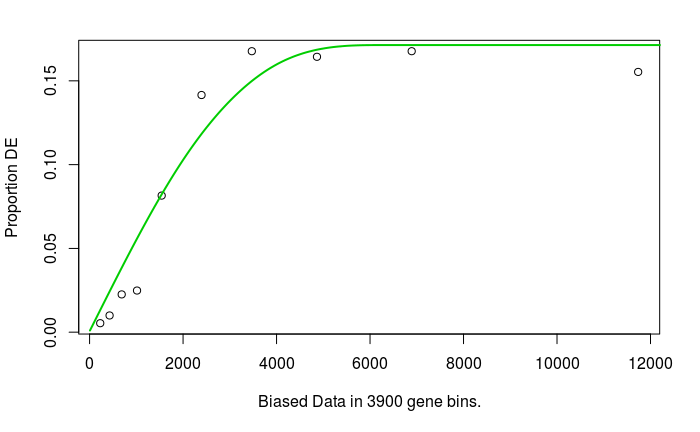

```r
load("data/geneLengths.RData")
subgroupAvsnonOAPathways<-getEnrichedReactomePathways(subgroupAvsnonOA,subgroupAvsnonOAsig,geneLengths)
```

```
initial point very close to some inequality constraints
```

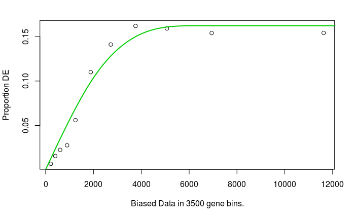

```r
subgroupBvsnonOAPathways<-getEnrichedReactomePathways(subgroupBvsnonOA,subgroupBvsnonOAsig,geneLengths)
```

```
initial point very close to some inequality constraints
```

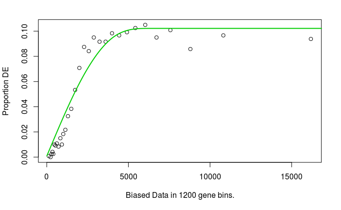

```r
subgroupBvssubgroupAPathways<-getEnrichedReactomePathways(subgroupBvssubgroupA,subgroupBvssubgroupAsig,geneLengths)
```

```r
write.xlsx(subgroupAvsnonOAPathways, file="results/reactomePathways.xlsx", sheetName="subgroupAvsnonOA",row.names = F)
write.xlsx(subgroupBvsnonOAPathways, file="results/reactomePathways.xlsx", sheetName="subgroupBvsnonOA", append=TRUE,row.names = F)
write.xlsx(subgroupBvssubgroupAPathways, file="results/reactomePathways.xlsx", sheetName="subgroupBvssubgroupA", append=TRUE,row.names = F)
```